# ORF Exploration

Tyler H. Matta

First, we must define the score distribution. Traditionally, we equate test forms that were taken within a single test window. That is, we have been working with univariate score distributions. In the context of repeated measures, one can choose to extend this approach by equating forms within a single time frame. That would result defining univariate score distributions at each time point, what we will call a multi-univariate appraoch.

Finally, since an objective of a reapeated meaures testing program is to measure growth, one could argue that the score distribution should be defined as multivariate. That is, rahter than ignore the the dependece structure resulting from the same examinees taking exams multiple times, we estimate the covariance.

There are two mains options for how one goes about defining the score distributions. First, one can use the sample data directly, often referred to as the empirical score distribution. Alternatively, one can define a model for the score distribution. Using the empirical score distribution is best when euquating is to be done for opertation tests where it is the sample of examinees who are of primary importance. However, a model-based distribution is defenisble when the scores come from a field test and the equating solution is to be used to reconcile form differences for future examinees. That is, the sample distribution is like to exhibit nuances that are unique to the sample and would not generalize, where the model-based appraoch would make the assumption that the observed field test data, and future data are generated from the same model.

In the current context we’re dealing with a linear equating solution, which requires a mean and a variance for a multi-univariate approach and mean vector and covariance matrix for a multidimensional approach.

In the multivariate context, one can go about computing the sample mean vector and sample covariance matrix as follows,

$$\mu = \frac{1}{N} \sum^{N}_{i = 1} y_{ij}, \; j = 1, \ldots, K$$

$$\Sigma = \frac{1}{N-1} \left( {\bf Y} - \bar{{\bf y}}{\bf 1}^{\prime}_{N} \right) \left( {\bf Y} - \bar{{\bf y}}{\bf 1}^{\prime}_{N} \right)^{\prime}$$

Alternatively, one can obrtain a model-implied moment by fitting a growth model to the repeated measures.
$${\bf y}_{i} = {\bf X}_{i} \, \beta + {\bf Z}_{i} \, \zeta_{i} + \epsilon_{i}$$
where
$$\epsilon_{i} \sim \mathcal{N}(0, \psi^{2}) \textrm{ and } \zeta_{i} \sim \mathcal{N}({\bf 0}, \mathrm{T})$$

We can then use the estimated fixed effects, $\beta$, estimated variance components, $\psi^{2}$ and $\mathrm{T}$, along with the design matrices ${\bf X}$ and ${\bf Z}$ to obtain the model implied mean and covariance matrices,

$$\begin{align}
\mu &= {\bf X} \, \beta \\
\Sigma &= {\bf Z} \, \mathrm{T} \, {\bf Z}^{\prime} + \psi^{2} \bf{I}
\end{align}$$

There are, of course, other ways one could go about establishing a mean and covariance. It is not currently obvious how onw would extend a model-based approach for equating solutions that require more information about the score distributions, e.g. equipercentile equating.

In what follows, describe the required design elements for putsue a repeated measures equating project. Next, we show how the multivariate linear equating solution generalizes the univariate linear equating solution through the multi-univariate approach. Next, we show how a multi-univariate solution results in different solution than the multivariate equating solutions. That is, constrining the off-diagonal elements of a covariance matrix indeed has an impact on the equating solution.

### Design

The task is to equate a set of linear forms onto a single scale such that students who are assessed throughout the year can be compared regardless of the test form used. The goal of such an assessment program is not only to understand where a student is in their reading ability today, often refered to as a status measure, but to understand how the students reading ability has changed over the course of some time period. Such a program assesses an examinne multiple times with a desire to infer from the changes in the test scores how a studnets reading ability has grown.

Examinees are randomly assigned to groups, enabling the common group assumption. This assumption not only supposes that the ability distribution is the same at the start, but that the distribution of ability over time remains equal.

Once group should be adminstered the same for at each time point. We call this the achor for as it is the one that all other forms will be equated to. By using an anchor form at each time point, we are able to understand how the ability distribution changes over time. That is, for the anchor group we assume the test characteristics remain unchanged, and it is ability that is changing over time. For this to hold, we must assume that changes in ability are not triggered by practice effects. This is a testable assumption with a proper design. If the test is violated, one could conceivably correct for the practice effects.

Finally, all reamaining groups can be adminstered differing forms at each time point.

```
##
##       1   2   3   4
##   1 227   0   0 152
##   2   0 280   0 187
##   3   0   0 279 166
```

### WpM Distributions

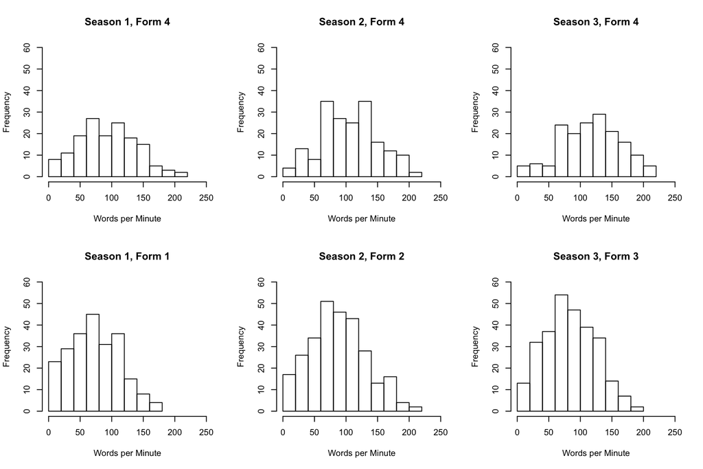

### Univariate linear equating

Kolen and Brennan define a linear equating solution as:

$$l_{a}(b) = \frac{\sigma_{a}}{\sigma_{b}} \mu_{b} + \left[ \mu_{a} - \frac{\sigma_{a}}{\sigma_{b}}\mu_{b} \right]$$

where $(\mu_{a}, \, \sigma_{a})$ and $(\mu_{b}, \, \sigma_{b})$ are the empirical means and standard deviations for the anchor form and corresponding benchmark form, respectively.

#### Empirical moments

We start by computing the empirical means and variances for the anchor form at each season. The means reside in `yEmpMeanVec` while the variances reside in `yEmpVarVec`, and `yEmpSdVec` contains the standard deviations.

|  | 1 | 2 | 3 |
| --- | --- | --- | --- |
| yEmpMeanVec | 93.29605 | 105.96791 | 115.96988 |
| yEmpVarVec | 2005.45482 | 1925.96671 | 2080.72030 |
| yEmpSdVec | 44.78230 | 43.88584 | 45.61491 |

We do the same for each of the benchmark forms.

```r
xEmpMeanVec <- c(mean(ttl_g$total[ttl_g$probe_id == 1]),
                 mean(ttl_g$total[ttl_g$probe_id == 2]),
                 mean(ttl_g$total[ttl_g$probe_id == 3]))

xEmpVarVec <- c(var(ttl_g$total[ttl_g$probe_id == 1]),
                var(ttl_g$total[ttl_g$probe_id == 2]),
                var(ttl_g$total[ttl_g$probe_id == 3]))

xEmpSdVec <-  sqrt(xEmpVarVec)

xEmpMat <- rbind(xEmpMeanVec, xEmpVarVec, xEmpSdVec)
colnames(xEmpMat) <- c("1", "2", "3")

xEmpMat %>%
 kable() %>%
  kable_styling(bootstrap_options = "striped", full_width = F, position = "left")
```

|  | 1 | 2 | 3 |
| --- | --- | --- | --- |
| xEmpMeanVec | 73.76652 | 87.91071 | 84.29391 |
| xEmpVarVec | 1536.07356 | 1959.97408 | 1628.42410 |
| xEmpSdVec | 39.19277 | 44.27159 | 40.35374 |

#### Linear equating function

We can equate the tests using empirical variances instead of standard deviations. This solution proves more general when moving to a matrix solution.

$$l_{a}(b) = \left(\frac{\sigma^{2}_{a}}{\sigma^{2}_{b}} \right)^{1/2} \mu_{b} + \left[ \mu_{a} - \left(\frac{\sigma^{2}_{a}}{\sigma^{2}_{b}} \right)^{1/2}\mu_{b} \right]$$

The following demonstrates that the equation above, namely taking the square root of the divisor of the variances is identical to divding the standard deviations.

```r
xVec <- seq(from = 75, to = 175, by = 5)

linEqXToYSd <- linear_equate_x_to_y1(x      = xVec,
                     muY    = yEmpMeanVec[1],
                     sigmaY = yEmpSdVec[1],
                     muX    = xEmpMeanVec[1],
                     sigmaX = xEmpSdVec[1])

linEqXToYVar <- linear_equate_x_to_y2(x      = xVec,
                     muY    = yEmpMeanVec[1],
                     sigmaY = yEmpVarVec[1],
                     muX    = xEmpMeanVec[1],
                     sigmaX = xEmpVarVec[1])

cbind(raw = linEqXToYSd[, 1], "u-eq1" = linEqXToYSd[, 2], "u-eq2" = linEqXToYVar[, 2])
```

```
##       raw u-eq1 u-eq2
##  [1,]  75    95    95
##  [2,]  80   100   100
##  [3,]  85   106   106
##  [4,]  90   112   112
##  [5,]  95   118   118
##  [6,] 100   123   123
##  [7,] 105   129   129
##  [8,] 110   135   135
##  [9,] 115   140   140
## [10,] 120   146   146
## [11,] 125   152   152
## [12,] 130   158   158
## [13,] 135   163   163
## [14,] 140   169   169
## [15,] 145   175   175
## [16,] 150   180   180
## [17,] 155   186   186
## [18,] 160   192   192
## [19,] 165   198   198
## [20,] 170   203   203
## [21,] 175   209   209
```

### Multivariate linear equating

Now, suppose we want to extend the univariate linking solution to equate a set of scores based on a set of means and covariances. That is, rather than input a scalar value for the mean and variance, we utilize a vector valued mean and covariance matrix. The linear equating solution extends to
$$l_{a}(b) = \textrm{Chol}\left(\Sigma_{a}\Sigma_{b}^{-1}\right) \mu_{b} + \left[ \mu_{a} -\textrm{Chol}\left(\Sigma_{a}\Sigma_{b}^{-1}\right) \mu_{b} \right]$$

We first demonstrate that equating each benchmarks to the repeated anchor form is equivalent to the multivariate equating when the off-diagonal of the covariance matrix is assumed to be zero. We do this with a subset of responses in the data. That is, we use the following elements for with the multivariate equating function

```
## $`Y Mean Vector`
## [1]  93.29605 105.96791 115.96988
##
## $`Y Variances`
##          [,1]     [,2]    [,3]
## [1,] 2005.455    0.000    0.00
## [2,]    0.000 1925.967    0.00
## [3,]    0.000    0.000 2080.72
##
## $`X Mean Vector`
## [1] 73.76652 87.91071 84.29391
##
## $`X Variances`
##          [,1]     [,2]     [,3]
## [1,] 1536.074    0.000    0.000
## [2,]    0.000 1959.974    0.000
## [3,]    0.000    0.000 1628.424
```

```r
equate_out <- list()

for(jj in 1:nrow(sub1_ttl_g_w))
{
  xVec_j <-  t(unname(as.matrix(sub1_ttl_g_w[jj, ])))

  mvOut <- mv_linear_equate_x_to_y(xVec = xVec_j,
                yMeanVec = yEmpMeanVec,
                yCovMat = diag(yEmpVarVec),
                xMeanVec = xEmpMeanVec,
                xCovMat = diag(xEmpVarVec))


  uvOut <- linear_equate_x_to_y2(x = xVec_j,
                        muY    = yEmpMeanVec,
                        sigmaY = yEmpVarVec,
                        muX    = xEmpMeanVec,
                        sigmaX = xEmpVarVec)

  equate_out[[jj]] <- cbind("raw" = uvOut[, 1], "u-eq" = uvOut[, 2], "m-eq" = mvOut[, 2])
  rownames(equate_out[[jj]]) <- paste("Season", 1:3)

}
```

We see that based on the first 10 score sequences, the results from `mv_linear_equate_x_to_y` equal that of `linear_equate_x_to_y2`.

```
## [[1]]
##          raw u-eq m-eq
## Season 1 155  186  186
## Season 2 162  179  179
## Season 3 158  199  199
##
## [[2]]
##          raw u-eq m-eq
## Season 1 118  144  144
## Season 2 133  151  151
## Season 3 133  171  171
##
## [[3]]
##          raw u-eq m-eq
## Season 1  90  112  112
## Season 2  94  112  112
## Season 3 116  152  152
##
## [[4]]
##          raw u-eq m-eq
## Season 1   8   18   18
## Season 2  10   29   29
## Season 3  15   38   38
##
## [[5]]
##          raw u-eq m-eq
## Season 1 136  164  164
## Season 2 125  143  143
## Season 3 145  185  185
##
## [[6]]
##          raw u-eq m-eq
## Season 1  57   74   74
## Season 2  55   73   73
## Season 3  53   81   81
##
## [[7]]
##          raw u-eq m-eq
## Season 1  82  103  103
## Season 2  79   97   97
## Season 3  73  103  103
##
## [[8]]
##          raw u-eq m-eq
## Season 1  92  114  114
## Season 2  97  115  115
## Season 3 113  148  148
##
## [[9]]
##          raw u-eq m-eq
## Season 1  69   88   88
## Season 2  83  101  101
## Season 3  94  127  127
##
## [[10]]
##          raw u-eq m-eq
## Season 1  74   94   94
## Season 2 125  143  143
## Season 3 125  162  162
```

### Multivariate linear equating with model-implied moments

We now use `mv_linear_equate_x_to_y` to equate the benchmark forms using model-implied moments based on mixed models that account for individual growth.

### Model-based means and covariance matrix

```r
J <- max(unique(ttl_g$season))
int <- rep(1, J)
slp <- seq(0, J-1)
Z <- X <- as.matrix(cbind(int, slp))
```

### Random intercepts model

Next, we fit

```r
aM1 <- lmer(total ~ 1 + season + (1 | anon_id), data = ttl_g[ttl_g$probe_id %in% anchorId, ])
bM1 <- lmer(total ~ 1 + season + (1 | anon_id), data = ttl_g[ttl_g$probe_id %in% benchmarkId, ])

#-- extract variance components
aVarComp <- as.data.frame(VarCorr(aM1, order = "lower.tri"))$vcov

aVar   <- aVarComp[1]
aResid <- aVarComp[2]

bVarComp <- as.data.frame(VarCorr(bM1, order = "lower.tri"))$vcov

bVar   <- bVarComp[1]
bResid <- bVarComp[2]

#-- compute marginal means and covariance matrix
aM1CovMat <- diag(rep(aVar, J)) + diag(rep(aResid, nrow(Z)))
aM1MeanVec <- X %*% fixef(aM1)

bM1CovMat <- diag(rep(bVar, J)) + diag(rep(bResid, nrow(Z)))
bM1MeanVec <- X %*% fixef(bM1)

list(aM1MeanVec, aM1CovMat, bM1MeanVec, bM1CovMat)
```

```
## [[1]]
##           [,1]
## [1,]  81.83808
## [2,]  92.64655
## [3,] 103.45502
##
## [[2]]
##          [,1]     [,2]     [,3]
## [1,] 2040.819    0.000    0.000
## [2,]    0.000 2040.819    0.000
## [3,]    0.000    0.000 2040.819
##
## [[3]]
##          [,1]
## [1,] 66.82968
## [2,] 73.51972
## [3,] 80.20977
##
## [[4]]
##         [,1]    [,2]    [,3]
## [1,] 1737.85    0.00    0.00
## [2,]    0.00 1737.85    0.00
## [3,]    0.00    0.00 1737.85
```

### Random intercepts and trend model

Next, we fit

```r
aM2 <- lmer(total ~ 1 + season + (1 + season | anon_id), data = ttl_g[ttl_g$probe_id %in% anchorId, ])
bM2 <- lmer(total ~ 1 + season + (1 + season | anon_id), data = ttl_g[ttl_g$probe_id %in% benchmarkId, ])

#-- extract variance components
aVarComp <- as.data.frame(VarCorr(aM2, order = "lower.tri"))$vcov

aCovMat <- matrix(NA, 2, 2)
aCovMat[1, 1] <- aVarComp[1]
aCovMat[2, 2] <- aVarComp[2]
aCovMat[1, 2] <- aCovMat[2, 1] <- aVarComp[3]
aResid <- aVarComp[4]

bVarComp <- as.data.frame(VarCorr(bM2, order = "lower.tri"))$vcov

bCovMat <- matrix(NA, 2, 2)
bCovMat[1, 1] <- bVarComp[1]
bCovMat[2, 2] <- bVarComp[2]
bCovMat[1, 2] <- bCovMat[2, 1] <- bVarComp[3]
bResid <- bVarComp[4]

#-- compute marginal means and covariance matrix
aM2CovMat <- Z %*% aCovMat %*% t(Z) + diag(rep(aResid, nrow(Z)))
aM2MeanVec <- X %*% fixef(aM1)

bM2CovMat <- Z %*% bCovMat %*% t(Z) + diag(rep(bResid, nrow(Z)))
bM2MeanVec <- X %*% fixef(bM1)
```

We then use the full covariance in the equating solution as well as the covariance matrix with the off-diagonals constrained to zero. Note that we are only doing this for purposes of comparison.

```
## [[1]]
##           [,1]
## [1,]  81.83808
## [2,]  92.64655
## [3,] 103.45502
##
## [[2]]
##          [,1]     [,2]     [,3]
## [1,] 2253.772 1968.034 1849.639
## [2,] 1968.034 2073.338 1843.955
## [3,] 1849.639 1843.955 2005.614
##
## [[3]]
##          [,1]
## [1,] 66.82968
## [2,] 73.51972
## [3,] 80.20977
##
## [[4]]
##          [,1]     [,2]     [,3]
## [1,] 1608.997 1432.258 1462.112
## [2,] 1432.258 1669.342 1493.238
## [3,] 1462.112 1493.238 1730.957
```

```
## [[1]]
##           [,1]
## [1,]  81.83808
## [2,]  92.64655
## [3,] 103.45502
##
## [[2]]
##          [,1]     [,2]     [,3]
## [1,] 2253.772    0.000    0.000
## [2,]    0.000 2073.338    0.000
## [3,]    0.000    0.000 2005.614
##
## [[3]]
##          [,1]
## [1,] 66.82968
## [2,] 73.51972
## [3,] 80.20977
##
## [[4]]
##          [,1]     [,2]     [,3]
## [1,] 1608.997    0.000    0.000
## [2,]    0.000 1669.342    0.000
## [3,]    0.000    0.000 1730.957
```

#### Multidimensional Equating

Equating with vector of model implied means and covariance matrices compared to empirical variances.

- `s-eq1` uses of the sample means and variances
- `m-eq1` uses of the random intercept model-implied means and variances (contraining the covariances to zero)
- `m-eq2(1)` uses of the random coefficient model-implied means and variances (contraining the covariances to zero)
- `m-eq2(2)` uses of the model-implied means and covariance matrix (same variances as `m-eq2` with covariances unconstrained)

```r
compare_equate_out2 <- list()

for (jj in 1:nrow(sub1_ttl_g_w))
{
  xVec_j <-  t(unname(as.matrix(sub1_ttl_g_w[jj, ])))

  mvS1Out <- mv_linear_equate_x_to_y(xVec    = xVec_j,
                                    yMeanVec = yEmpMeanVec,
                                    yCovMat  = diag(yEmpVarVec),
                                    xMeanVec = xEmpMeanVec,
                                    xCovMat  = diag(xEmpVarVec))

  mvM1Out <- mv_linear_equate_x_to_y(x        = xVec_j,
                                    yMeanVec = aM1MeanVec,
                                    yCovMat  = diag(diag(aM1CovMat)),
                                    xMeanVec = bM1MeanVec,
                                    xCovMat  = diag(diag(bM1CovMat)))

  mvM21Out <- mv_linear_equate_x_to_y(x        = xVec_j,
                                    yMeanVec = aM2MeanVec,
                                    yCovMat  = diag(diag(aM2CovMat)),
                                    xMeanVec = bM2MeanVec,
                                    xCovMat  = diag(diag(bM2CovMat)))

  mvM22Out <- mv_linear_equate_x_to_y(x        = xVec_j,
                                    yMeanVec = aM2MeanVec,
                                    yCovMat  = aM2CovMat,
                                    xMeanVec = bM2MeanVec,
                                    xCovMat  = bM2CovMat)

  compare_equate_out2[[jj]] <- cbind("raw"   = mvS1Out[, 1],
                                     "s-eq1" = mvS1Out[, 2],
                                     "m-eq1" = mvM1Out[, 2],
                                     "m-eq2(1)" = mvM21Out[, 2],
                                     "m-eq2(2)" = mvM22Out[, 2])
  rownames(compare_equate_out2[[jj]]) <- paste("Season", 1:3)
}

compare_equate_out2[1:10]
```

```
## [[1]]
##          raw s-eq1 m-eq1 m-eq2(1) m-eq2(2)
## Season 1 155   186   177      186      177
## Season 2 162   179   189      191      158
## Season 3 158   199   188      187      157
##
## [[2]]
##          raw s-eq1 m-eq1 m-eq2(1) m-eq2(2)
## Season 1 118   144   137      142      135
## Season 2 133   151   157      159      136
## Season 3 133   171   161      160      140
##
## [[3]]
##          raw s-eq1 m-eq1 m-eq2(1) m-eq2(2)
## Season 1  90   112   107      109      100
## Season 2  94   112   115      115      103
## Season 3 116   152   142      142      128
##
## [[4]]
##          raw s-eq1 m-eq1 m-eq2(1) m-eq2(2)
## Season 1   8    18    18       12       23
## Season 2  10    29    24       22       48
## Season 3  15    38    33       33       59
##
## [[5]]
##          raw s-eq1 m-eq1 m-eq2(1) m-eq2(2)
## Season 1 136   164   157      164      153
## Season 2 125   143   148      150      125
## Season 3 145   185   174      173      148
##
## [[6]]
##          raw s-eq1 m-eq1 m-eq2(1) m-eq2(2)
## Season 1  57    74    71       70       78
## Season 2  55    73    73       72       82
## Season 3  53    81    74       74       85
##
## [[7]]
##          raw s-eq1 m-eq1 m-eq2(1) m-eq2(2)
## Season 1  82   103    98      100      106
## Season 2  79    97    99       99      100
## Season 3  73   103    96       96       98
##
## [[8]]
##          raw s-eq1 m-eq1 m-eq2(1) m-eq2(2)
## Season 1  92   114   109      112      104
## Season 2  97   115   118      119      107
## Season 3 113   148   139      139      126
##
## [[9]]
##          raw s-eq1 m-eq1 m-eq2(1) m-eq2(2)
## Season 1  69    88    84       84       80
## Season 2  83   101   103      103       98
## Season 3  94   127   118      118      113
##
## [[10]]
##          raw s-eq1 m-eq1 m-eq2(1) m-eq2(2)
## Season 1  74    94    90       90       79
## Season 2 125   143   148      150      131
## Season 3 125   162   152      152      134
```

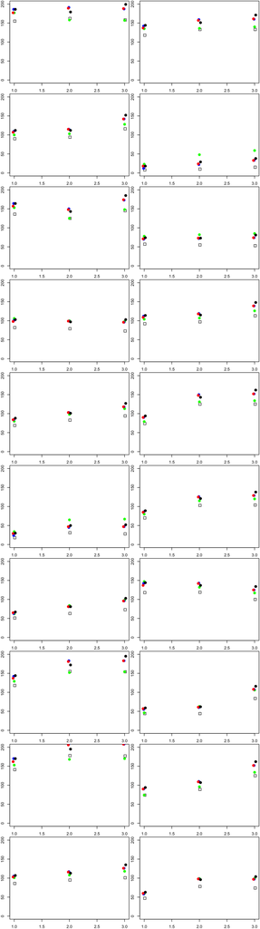